# Tugas-Pertemuan-3

## Pengantar

Dalam pemodelan deret waktu, sering kali efek dari suatu kejadian (variabel X) terhadap target observasi (variabel Y) tidak terjadi secara instan, melainkan membutuhkan jeda waktu atau **Lag**.

Secara umum, terdapat tiga pendekatan utama untuk memodelkan efek jeda waktu ini:

1. **Distributed Lag Model (DLM):** Variabel dependen (Y) dipengaruhi oleh variabel independen saat ini dan masa lalu ($X_t, X_{t-1}, X_{t-2}$, dst).
2. **Autoregressive Model (AR):** Variabel dependen (Y) dipengaruhi oleh variabel independen saat ini ($X_t$) dan nilai dirinya sendiri di masa lalu ($Y_{t-1}, Y_{t-2}$, dst).
3. **Autoregressive Distributed Lag (ARDL):** Model gabungan di mana Y dipengaruhi oleh X saat ini, X masa lalu, dan Y masa lalu.

# 1. Persiapan Data

## a. Library

```r
# Mengaktifkan library yang dibutuhkan
# install.packages(c("dLagM", "dynlm", "MLmetrics", "lmtest", "car")) # Run jika belum meng-install

library(dLagM)
library(dynlm)
library(MLmetrics)
library(lmtest)
library(car)
```

## b. Import Data

```r
# Impor data
data <- read.csv("NewDelhi_Air_quality.csv")

# Melihat data
head(data)
```

```
##   X  AQI       CO      datetime        no2       o3      pm10     pm25
## 1 0 30.2 198.6027 2022-10-21:18 0.04685717 55.78995 10.486722 5.637410
## 2 1 28.2 197.6013 2022-10-21:19 0.04645554 54.93164 10.719325 4.618169
## 3 2 26.6 198.6027 2022-10-21:20 0.04685717 54.64554 11.155578 3.520902
## 4 3 25.0 201.9405 2022-10-21:21 0.04819594 55.07469 11.116206 2.225919
## 5 4 26.0 205.2784 2022-10-21:22 0.04886533 55.78995 10.405250 1.979471
## 6 5 26.0 208.6163 2022-10-21:23 0.05020411 56.50520  9.402518 1.792677
##         so2     timestamp_local       timestamp_utc         ts
## 1 0.3874302 2022-10-21T23:00:00 2022-10-21T18:00:00 1666375200
## 2 0.4097819 2022-10-22T00:00:00 2022-10-21T19:00:00 1666378800
## 3 0.4023313 2022-10-22T01:00:00 2022-10-21T20:00:00 1666382400
## 4 0.3762543 2022-10-22T02:00:00 2022-10-21T21:00:00 1666386000
## 5 0.3390014 2022-10-22T03:00:00 2022-10-21T22:00:00 1666389600
## 6 0.3129244 2022-10-22T04:00:00 2022-10-21T23:00:00 1666393200
```

```r
# Melihat struktur data
str(data)
```

```
## 'data.frame':    72 obs. of  12 variables:
##  $ X              : int  0 1 2 3 4 5 6 7 8 9 ...
##  $ AQI            : num  30.2 28.2 26.6 25 26 26 26 24 23 24 ...
##  $ CO             : num  199 198 199 202 205 ...
##  $ datetime       : chr  "2022-10-21:18" "2022-10-21:19" "2022-10-21:20" "2022-10-21:21" ...
##  $ no2            : num  0.0469 0.0465 0.0469 0.0482 0.0489 ...
##  $ o3             : num  55.8 54.9 54.6 55.1 55.8 ...
##  $ pm10           : num  10.5 10.7 11.2 11.1 10.4 ...
##  $ pm25           : num  5.64 4.62 3.52 2.23 1.98 ...
##  $ so2            : num  0.387 0.41 0.402 0.376 0.339 ...
##  $ timestamp_local: chr  "2022-10-21T23:00:00" "2022-10-22T00:00:00" "2022-10-22T01:00:00" "2022-10-22T02:00:00" ...
##  $ timestamp_utc  : chr  "2022-10-21T18:00:00" "2022-10-21T19:00:00" "2022-10-21T20:00:00" "2022-10-21T21:00:00" ...
##  $ ts             : int  1666375200 1666378800 1666382400 1666386000 1666389600 1666393200 1666396800 1666400400 1666404000 1666407600 ...
```

## c. Memilih Peubah yang Digunakan

Dataset `NewDelhi_Air_quality.csv` terdiri atas 72 observasi. Pada analisis ini, Air Quality Index (AQI) ditetapkan sebagai variabel dependen (Y), sedangkan konsentrasi ozon (O₃) dipilih sebagai variabel independen (X). Pemilihan O₃ didasarkan pada hubungan yang paling kuat dengan AQI dibandingkan dengan polutan kandidat lainnya pada data yang digunakan.

```r
# Memilih peubah yang digunakan
data <- data[, c("datetime", "AQI", "o3")]

# Membuat nama peubah sesuai dengan HTML
data$Yt <- data$AQI
data$Xt <- data$o3

# Melihat data
head(data)
```

```
##        datetime  AQI       o3   Yt       Xt
## 1 2022-10-21:18 30.2 55.78995 30.2 55.78995
## 2 2022-10-21:19 28.2 54.93164 28.2 54.93164
## 3 2022-10-21:20 26.6 54.64554 26.6 54.64554
## 4 2022-10-21:21 25.0 55.07469 25.0 55.07469
## 5 2022-10-21:22 26.0 55.78995 26.0 55.78995
## 6 2022-10-21:23 26.0 56.50520 26.0 56.50520
```

| Peubah | Keterangan |
| --- | --- |
| `datetime` | waktu pengamatan |
| `AQI` / `Yt` | peubah respon |
| `o3` / `Xt` | peubah bebas |

## d. Membagi Data

Selanjutnya, data dibagi menjadi data training dan testing. Sebanyak 80% observasi pertama, yaitu 57 observasi, digunakan sebagai data training untuk membentuk model, sedangkan 20% observasi terakhir, yaitu 15 observasi, digunakan sebagai data testing untuk mengevaluasi kemampuan peramalan model.

```r
# Membagi data menjadi training dan testing
n <- nrow(data)

n.train <- floor(0.8 * n)

train <- data[1:n.train, ]
test <- data[(n.train + 1):n, ]

# Mengubah format data menjadi objek Time Series (ts)
train.ts <- ts(train)
test.ts <- ts(test)
data.ts <- ts(data)
```

```r
# Jumlah observasi
nrow(train)
```

```
## [1] 57
```

```r
nrow(test)
```

```
## [1] 15
```

```r
# Data training
head(train)
```

```
##        datetime  AQI       o3   Yt       Xt
## 1 2022-10-21:18 30.2 55.78995 30.2 55.78995
## 2 2022-10-21:19 28.2 54.93164 28.2 54.93164
## 3 2022-10-21:20 26.6 54.64554 26.6 54.64554
## 4 2022-10-21:21 25.0 55.07469 25.0 55.07469
## 5 2022-10-21:22 26.0 55.78995 26.0 55.78995
## 6 2022-10-21:23 26.0 56.50520 26.0 56.50520
```

```r
# Data testing
head(test)
```

```
##         datetime AQI       o3 Yt       Xt
## 58 2022-10-24:03  23 50.78316 23 50.78316
## 59 2022-10-24:04  22 47.92213 22 47.92213
## 60 2022-10-24:05  21 45.41874 21 45.41874
## 61 2022-10-24:06  20 43.98823 20 43.98823
## 62 2022-10-24:07  19 41.84246 19 41.84246
## 63 2022-10-24:08  19 41.48483 19 41.48483
```

# 2. Model Koyck

Model Koyck mengatasi masalah infinite distributed lag (pengaruh masa lalu yang tak terhingga) dengan mengasumsikan bahwa semakin jauh jarak lag, semakin kecil pengaruhnya.

Melalui transformasi aljabar, efek masa lalu dari X yang sangat panjang diringkas ke dalam satu variabel saja, yaitu $Y_{t-1}$. Bentuk persamaannya menjadi:

$$Y_t=a(1-\lambda)+\beta_0X_t+\lambda
Y_{t-1}+V_t$$

Catatan: $V_t$ adalah error term gabungan. Pada hasil ringkasan model (estimasi), $V_t$ tidak ditampilkan karena nilai harapannya diasumsikan nol.

## a. Pemodelan Koyck

Pemodelan ini menggunakan fungsi `koyckDlm()`.

```r
# Model Koyck
model.koyck <- koyckDlm(
  x = train$Xt,
  y = train$Yt
)

# Ringkasan model
summary(model.koyck)
```

```
##
## Call:
## "Y ~ (Intercept) + Y.1 + X.t"
##
## Residuals:
##       Min        1Q    Median        3Q       Max
## -1.127670 -0.301407  0.001002  0.262601  1.103471
##
## Coefficients:
##             Estimate Std. Error t value Pr(>|t|)
## (Intercept)  0.54798    0.92878   0.590    0.558
## Y.1          0.41955    0.08223   5.102 4.63e-06 ***
## X.t          0.25830    0.04107   6.289 6.25e-08 ***
## ---
## Signif. codes:  0 '***' 0.001 '**' 0.01 '*' 0.05 '.' 0.1 ' ' 1
##
## Residual standard error: 0.5053 on 53 degrees of freedom
## Multiple R-Squared: 0.9463,  Adjusted R-squared: 0.9443
## Wald test: 423.7 on 2 and 53 DF,  p-value: < 2.2e-16
##
## Diagnostic tests:
## NULL
##
##                             alpha      beta       phi
## Geometric coefficients:  0.944071 0.2582957 0.4195528
```

```r
# Goodness of Fit
GoF(model.koyck)
```

```
##              n       MAE         MPE       MAPE      sMAPE      MASE       MSE
## model.koyck 56 0.3849916 -0.00049635 0.01435646 0.01433475 0.6015494 0.2416839
##                  MRAE    GMRAE
## model.koyck 589435374 7663.933
```

dengan $Y_t$ adalah **AQI** **(indeks kualitas udara)** dan $X_t$ adalah **O3 (konsentrasi ozon)**.

Model Koyck menunjukkan bahwa AQI tidak hanya berkaitan dengan kadar O3 saat ini, tetapi juga dipengaruhi oleh kondisi AQI pada periode sebelumnya. Koefisien lag AQI sebesar **0.41955** menunjukkan adanya ketergantungan AQI terhadap periode sebelumnya. Sementara itu, O3 saat ini memiliki hubungan positif yang signifikan dengan AQI.

Dari bagian **geometric coefficients**, diperoleh:

$$\alpha = 0.944071, \\ \beta = 0.2582957,
\\ \phi = 0.4195528$$

Nilai $\phi = 0.41955$ konsisten dengan koefisien $Y_{t-1}$ pada model Koyck, yang menunjukkan adanya **persistence** atau ketergantungan AQI terhadap nilai sebelumnya.

Selain itu, model memiliki $Adjusted \ R^2=94.43%$, sehingga mampu menjelaskan variasi AQI dengan sangat baik. Nilai **MAE sebesar 0.38499** menunjukkan rata-rata kesalahan prediksi model sekitar 0.385 satuan AQI.

## b. Peramalan Koyck

```r
# Forecast model Koyck
fore.koyck <- forecast(
  model = model.koyck,
  x = test$Xt,
  h = nrow(test)
)

# Hasil forecast
fore.koyck
```

```
## $forecasts
##  [1] 24.15387 23.05989 21.95429 21.12094 20.21706 19.74546 20.00947 20.67448
##  [9] 20.95348 21.07054 21.58152 23.08914 24.83015 26.29958 27.28558
##
## $call
## forecast.koyckDlm(model = model.koyck, x = test$Xt, h = nrow(test))
##
## attr(,"class")
## [1] "forecast.koyckDlm" "dLagM"
```

```r
# Menghitung MAPE
mape.koyck <- MAPE(
  fore.koyck$forecasts,
  test$Yt
)

cat("MAPE Model Koyck:", mape.koyck, "\n")
```

```
## MAPE Model Koyck: 0.03187326
```

Model Koyck menghasilkan **MAPE sebesar 0.03187326 atau 3.19%**. Artinya, rata-rata persentase kesalahan prediksi AQI terhadap nilai aktual adalah sekitar **3.19%**. Nilai MAPE yang relatif kecil ini menunjukkan bahwa model Koyck memiliki **kemampuan prediksi yang cukup baik** dalam meramalkan AQI pada data pengujian.

# 3. Regression with Distributed Lag (DLM)

Berbeda dengan Koyck, pemodelan DLM membatasi secara spesifik berapa periode memori masa lalu yang dilibatkan. Batasan ini direpresentasikan dengan parameter $q$ .

$$Y_t = \alpha + \beta_0X_t +
\beta_1X_{t-1} \ + ... + \ \beta_qX_{t-q} \ + \epsilon_t$$

## a. Pemodelan (Lag = 2)

Fungsi yang digunakan adalah `dlm()`. Parameter `q = 2` berarti kita memasukkan $X_t, X_{t-1}$, dan $X_{t-2}$.

```r
model.dlm <- dlm(
  x = train$Xt,
  y = train$Yt,
  q = 2
  )

summary(model.dlm)
```

```
##
## Call:
## lm(formula = model.formula, data = design)
##
## Residuals:
##      Min       1Q   Median       3Q      Max
## -0.45678 -0.35809 -0.02571  0.25176  1.40513
##
## Coefficients:
##              Estimate Std. Error t value Pr(>|t|)
## (Intercept) -0.052782   0.689979  -0.076    0.939
## x.t          0.476379   0.053816   8.852 6.95e-12 ***
## x.1         -0.005756   0.099095  -0.058    0.954
## x.2         -0.008392   0.055411  -0.151    0.880
## ---
## Signif. codes:  0 '***' 0.001 '**' 0.01 '*' 0.05 '.' 0.1 ' ' 1
##
## Residual standard error: 0.3501 on 51 degrees of freedom
## Multiple R-squared:  0.9751, Adjusted R-squared:  0.9736
## F-statistic:   666 on 3 and 51 DF,  p-value: < 2.2e-16
##
## AIC and BIC values for the model:
##       AIC      BIC
## 1 46.4728 56.50947
```

Model DLM dengan lag hingga **2 periode** menghasilkan **Adjusted** $R^2=0.9736$, sehingga model mampu menjelaskan sekitar **97.36% variasi AQI**. O3 saat ini ($x.t$) berpengaruh positif dan signifikan terhadap AQI dengan koefisien **0.47638** dan p-value <0.05. Sementara itu, O3 pada lag 1 dan lag 2 **tidak signifikan**. Nilai **AIC = 46.4728** dan **BIC = 56.5095** digunakan dalam evaluasi pemilihan model.

## b. Menentukan Lag Optimal DLM

Untuk menghindari coba-coba, bisa mencari nilai $q$ terbaik berdasarkan nilai *Akaike Information Criterion (AIC)* terkecil menggunakan fungsi `finiteDLMauto()`.

```r
model.dlm.opt <- finiteDLMauto(
  formula = Yt ~ Xt,
  data = data.frame(train),
  q.min = 1,
  q.max = 10,
  model.type = "dlm",
  error.type = "AIC",
  trace = TRUE
)
```

```r
model.dlm.opt
```

```
##    q - k    MASE      AIC      BIC     GMRAE   MBRAE R.Adj.Sq  Ljung-Box
## 10    10 0.35051 22.97129 47.02321 14499.820 0.49589  0.98302 0.35474502
## 3      3 0.39875 27.06744 39.00134  6447.089 0.49480  0.98198 0.10728965
## 5      5 0.38245 27.17252 42.78247  7468.898 0.49506  0.98252 0.17930776
## 4      4 0.39892 27.90158 41.69362  8742.382 0.49838  0.98187 0.16589034
## 9      9 0.38342 29.59952 52.05393 11575.966 0.50164  0.98105 0.83879203
## 6      6 0.38046 29.81810 47.20453  6019.920 0.48473  0.98200 0.19113496
## 7      7 0.39444 30.91101 50.03124  7435.980 0.49025  0.98199 0.27024407
## 8      8 0.40121 31.26668 52.07671 10182.702 0.51165  0.98151 0.41738843
## 2      2 0.42869 46.47280 56.50947  6714.446 0.48891  0.97365 0.08751929
## 1      1 0.50971 90.38861 98.49001  6923.684 0.40817  0.94126 0.16081431
```

Berdasarkan kriteria AIC, DLM dengan lag optimal adalah $q = 10$ karena memiliki nilai AIC paling kecil, yaitu 22.97129. Model $q = 10$ juga memiliki Adjusted $R^2$ tertinggi sebesar 0.98302 dan MASE terendah sebesar 0.35051, sehingga model ini memberikan kecocokan dan performa prediksi yang lebih baik dibandingkan model dengan jumlah lag lainnya.

## c. Membuat Ulang Model DLM dengan Lag Optimal

```r
# Model DLM dengan lag optimal
model.dlm.final <- dlm(
  x = train$Xt,
  y = train$Yt,
  q = 10
)

summary(model.dlm.final)
```

```
##
## Call:
## lm(formula = model.formula, data = design)
##
## Residuals:
##     Min      1Q  Median      3Q     Max
## -0.5204 -0.1663  0.0356  0.1624  0.5130
##
## Coefficients:
##              Estimate Std. Error t value Pr(>|t|)
## (Intercept) -0.294780   0.931786  -0.316  0.75361
## x.t          0.405638   0.063702   6.368 2.54e-07 ***
## x.1          0.159000   0.133129   1.194  0.24038
## x.2         -0.052741   0.126788  -0.416  0.67997
## x.3         -0.148621   0.121282  -1.225  0.22860
## x.4          0.143544   0.124404   1.154  0.25638
## x.5         -0.007047   0.123348  -0.057  0.95476
## x.6         -0.127683   0.123191  -1.036  0.30709
## x.7          0.287823   0.121937   2.360  0.02396 *
## x.8         -0.399437   0.121443  -3.289  0.00230 **
## x.9          0.304147   0.103813   2.930  0.00594 **
## x.10        -0.098958   0.048025  -2.061  0.04684 *
## ---
## Signif. codes:  0 '***' 0.001 '**' 0.01 '*' 0.05 '.' 0.1 ' ' 1
##
## Residual standard error: 0.2715 on 35 degrees of freedom
## Multiple R-squared:  0.9871, Adjusted R-squared:  0.983
## F-statistic: 243.1 on 11 and 35 DF,  p-value: < 2.2e-16
##
## AIC and BIC values for the model:
##        AIC      BIC
## 1 22.97129 47.02321
```

Model memiliki **AIC = 22.9713** dan **BIC = 47.0232**. Nilai AIC tersebut merupakan **yang paling kecil dibandingkan model DLM dengan jumlah lag lainnya**, sehingga berdasarkan AIC, $q = 10$ **dipilih sebagai lag optimal**.

## d. Peramalan DLM

```r
# Peramalan DLM dengan lag optimal
fore.dlm <- forecast(
  model = model.dlm.final,
  x = test$Xt,
  h = nrow(test)
)

fore.dlm
```

```
## $forecasts
##  [1] 23.40514 21.79122 20.75754 20.09325 19.25114 18.84865 19.56151 20.98076
##  [9] 21.17891 20.56410 21.57565 23.70751 26.47347 27.65902 27.98734
##
## $call
## forecast.dlm(model = model.dlm.final, x = test$Xt, h = nrow(test))
##
## attr(,"class")
## [1] "forecast.dlm" "dLagM"
```

```r
# Menghitung MAPE DLM
mape.dlm <- MAPE(
  fore.dlm$forecasts,
  test$Yt
)

cat("MAPE Model DLM Optimum:", mape.dlm, "\n")
```

```
## MAPE Model DLM Optimum: 0.01274404
```

Model DLM optimal menghasilkan **MAPE sebesar 0.01274404 atau 1.27%**. Artinya, rata-rata persentase kesalahan prediksi AQI terhadap nilai aktual hanya sekitar **1.27%**, sehingga model DLM memiliki **akurasi prediksi yang sangat baik**.

# 4. Autoregressive Distributed Lag (ARDL)

Model ARDL menggabungkan pengaruh dari peubah independen masa lalu dan peubah dependen masa lalu.

**Perhatian Notasi:**

Pada *package* `dLagM` (khusus fungsi `ardlDlm`), aturannya adalah:

- $p$ = panjang *lag* peubah independen ($X$).
- $q$ = panjang *lag* peubah dependen ($Y$).

## a. Model ARDL Awal

```r
model.ardl <- ardlDlm(
  formula = Yt ~ Xt,
  data = train,
  p = 1,
  q = 1
)

summary(model.ardl)
```

```
##
## Time series regression with "ts" data:
## Start = 2, End = 57
##
## Call:
## dynlm(formula = as.formula(model.text), data = data)
##
## Residuals:
##     Min      1Q  Median      3Q     Max
## -1.0261 -0.2582  0.1254  0.2988  0.8683
##
## Coefficients:
##             Estimate Std. Error t value Pr(>|t|)
## (Intercept) -0.14906    0.67926  -0.219    0.827
## Xt.t         0.47821    0.03429  13.946  < 2e-16 ***
## Xt.1        -0.22331    0.04692  -4.759 1.59e-05 ***
## Yt.1         0.45264    0.06656   6.801 1.03e-08 ***
## ---
## Signif. codes:  0 '***' 0.001 '**' 0.01 '*' 0.05 '.' 0.1 ' ' 1
##
## Residual standard error: 0.3812 on 52 degrees of freedom
## Multiple R-squared:   0.97,  Adjusted R-squared:  0.9683
## F-statistic: 561.2 on 3 and 52 DF,  p-value: < 2.2e-16
```

Model menunjukkan $Adjusted \ R^2 = 0.9683$, sehingga sekitar **96.83% variasi AQI** dapat dijelaskan oleh O3 saat ini, O3 periode sebelumnya, dan AQI periode sebelumnya.

Ketiga peubah tersebut **signifikan**. O3 saat ini berpengaruh positif ($0.47821$), O3 lag-1 berpengaruh negatif (**−0.22331**), sedangkan AQI lag-1 berpengaruh positif (**0.45264**). Secara keseluruhan, model juga signifikan dengan $p-value < 2.2 × 10^{-16}$.

## b. Menentukan Lag Optimal ARDL

```r
# Menentukan kombinasi lag optimal ARDL berdasarkan AIC
model.ardl.opt <- ardlBoundOrders(
  data = data.frame(train),
  ic = "AIC",
  formula = Yt ~ Xt
)

model.ardl.opt
```

```
## $p
##   Xt
## 1 12
##
## $q
## [1] 15
##
## $Stat.table
##           q = 1    q = 2    q = 3    q = 4     q = 5    q = 6    q = 7    q = 8
## p = 1  41.62720 26.97270 29.19019 31.33838 31.559929 32.30452 34.24756 35.86251
## p = 2  26.78053 28.78047 31.18861 32.82477 32.626876 32.48412 34.43235 36.32395
## p = 3  31.29643 31.29643 33.17310 34.82462 34.625049 31.83024 34.25710 36.24070
## p = 4  31.18772 32.66068 32.66068 31.38167 34.004907 33.82865 35.76008 38.00180
## p = 5  32.54160 33.56222 34.17049 34.17049 35.780138 35.44887 37.75107 39.55267
## p = 6  33.85448 35.23826 33.54028 35.45511 35.455105 37.44736 39.49332 41.48637
## p = 7  35.88917 36.74198 34.99216 36.18582 37.610874 37.61087 35.92830 31.49916
## p = 8  29.51226 31.01676 31.54177 32.83693 33.368087 34.98225 34.98225 33.32355
## p = 9  26.88007 28.73746 28.03980 30.03103 30.858499 31.75580 33.73155 33.73155
## p = 10 29.49819 31.38223 30.31552 32.24016 31.931235 33.21578 35.18391 36.85673
## p = 11 29.22497 29.73686 30.25521 32.21065 32.038190 33.52137 35.26896 37.18829
## p = 12 29.74354 30.54371 29.97316 31.87888 32.234613 33.77040 34.96145 36.42189
## p = 13 15.69837 14.67214 16.57830 12.44703  9.397706 11.27758 12.27515 14.27327
## p = 14 18.40620 17.80623 19.80549 19.89788 16.205748 18.04535 17.56353 19.52926
## p = 15 20.48056 19.03075 20.94731 19.16028 17.418732 17.11506 18.55434 20.35437
##           q = 9     q = 10    q = 11     q = 12    q = 13    q = 14      q = 15
## p = 1  36.66464 36.0715657 37.064266 38.3740578 39.653612 34.300375  25.0742390
## p = 2  37.73984 38.0656900 38.521095 39.8539885 41.243035 36.275747  26.9807007
## p = 3  36.47863 36.8841698 38.695519 40.1147745 39.365534 34.689775  26.1260035
## p = 4  38.40771 38.7990855 40.689293 42.1137443 40.088013 34.873540  26.0721908
## p = 5  39.80584 39.9055340 41.672555 43.6528287 42.085896 36.770735  28.0368623
## p = 6  39.36207 39.2361081 39.855677 42.3782175 42.688201 33.186885  22.4219291
## p = 7  34.29065 36.8955779 38.505491 41.3640312 42.343455 29.198872  17.1576296
## p = 8  34.69032 36.8920154 33.326495 36.1047660 34.438764 26.878258  19.1569900
## p = 9  35.52779 38.4425736 34.181590 35.3186897 32.290026 21.310984   4.4581015
## p = 10 36.85673 37.9241685 30.535472 33.4698869 33.889598 22.949870  -0.6937812
## p = 11 34.19420 34.1942039 32.478995 34.0882549 34.883985 22.670261   0.6547787
## p = 12 33.92112 35.5798210 35.579821 35.7948234 26.767371  1.190264 -12.2760626
## p = 13 12.49969 10.2044813  8.939400  8.9394000 10.866027  3.140641 -11.2487162
## p = 14 18.56133 18.7258984 20.504152 -8.1264294 -8.126429 -6.411649  -9.2595385
## p = 15 15.56244 -0.1189099  1.548441 -0.6220571 -9.958942 -9.958942  -9.5156613
##
## $min.Stat
## [1] -12.27606
```

```r
# Menentukan kombinasi lag optimal berdasarkan AIC
min_p <- sapply(model.ardl.opt$Stat.table, min, na.rm = TRUE)

q.opt <- which.min(min_p)

p.opt <- which.min(model.ardl.opt$Stat.table[[q.opt]])

data.frame(
  "Lag_Y_opt(q)" = q.opt,
  "Lag_X_opt(p)" = p.opt,
  "AIC" = model.ardl.opt$min.Stat
)
```

```
##        Lag_Y_opt.q. Lag_X_opt.p.       AIC
## q = 15           15           12 -12.27606
```

Berdasarkan hasil pemilihan lag, model **ARDL optimal menggunakan lag AQI** $q$ **= 15 dan lag O3** $p$ **= 12**. Model tersebut dipilih berdasarkan nilai **AIC minimum sebesar −12.27606**, sehingga kombinasi lag 15 untuk AQI dan lag 12 untuk O3 merupakan kombinasi terbaik berdasarkan kriteria AIC.

## c. Membuat Ulang Model ARDL dengan Lag Optimal

```r
# Model ARDL dengan lag optimal
model.ardl.final <- ardlDlm(
  formula = Yt ~ Xt,
  data = train,
  p = 12,
  q = 15
)

summary(model.ardl.final)
```

```
##
## Time series regression with "ts" data:
## Start = 16, End = 57
##
## Call:
## dynlm(formula = as.formula(model.text), data = data)
##
## Residuals:
##     Min      1Q  Median      3Q     Max
## -0.3377 -0.1108 -0.0081  0.1271  0.3114
##
## Coefficients:
##              Estimate Std. Error t value Pr(>|t|)
## (Intercept) -2.211528   1.438210  -1.538 0.148101
## Xt.t         0.515866   0.113669   4.538 0.000557 ***
## Xt.1         0.060249   0.299072   0.201 0.843463
## Xt.2         0.102010   0.327845   0.311 0.760618
## Xt.3         0.237641   0.379722   0.626 0.542259
## Xt.4         0.053505   0.367245   0.146 0.886398
## Xt.5         0.028742   0.340049   0.085 0.933929
## Xt.6         0.061109   0.341669   0.179 0.860809
## Xt.7         0.497571   0.216698   2.296 0.038936 *
## Xt.8        -0.418993   0.243475  -1.721 0.108968
## Xt.9         0.004725   0.267651   0.018 0.986183
## Xt.10        0.293760   0.255349   1.150 0.270692
## Xt.11        0.043751   0.291187   0.150 0.882873
## Xt.12       -0.208998   0.245440  -0.852 0.409891
## Yt.1        -0.322377   0.252482  -1.277 0.223999
## Yt.2        -0.143197   0.318197  -0.450 0.660105
## Yt.3        -0.413646   0.378150  -1.094 0.293868
## Yt.4        -0.246960   0.366292  -0.674 0.511986
## Yt.5         0.010252   0.395014   0.026 0.979688
## Yt.6        -0.393970   0.376224  -1.047 0.314102
## Yt.7        -0.315106   0.283585  -1.111 0.286631
## Yt.8         0.180590   0.355011   0.509 0.619492
## Yt.9         0.074599   0.375664   0.199 0.845663
## Yt.10       -0.332312   0.262679  -1.265 0.228047
## Yt.11       -0.146205   0.277029  -0.528 0.606558
## Yt.12        0.251928   0.283023   0.890 0.389571
## Yt.13        0.077188   0.166933   0.462 0.651445
## Yt.14       -0.119917   0.107394  -1.117 0.284377
## Yt.15        0.161404   0.069770   2.313 0.037711 *
## ---
## Signif. codes:  0 '***' 0.001 '**' 0.01 '*' 0.05 '.' 0.1 ' ' 1
##
## Residual standard error: 0.2789 on 13 degrees of freedom
## Multiple R-squared:  0.9946, Adjusted R-squared:  0.9829
## F-statistic: 85.17 on 28 and 13 DF,  p-value: 8.163e-11
```

Model ARDL optimal menggunakan **lag AQI = 15** dan **lag O3 = 12**. Model memiliki **Adjusted** $R^2 = 0.9829$, sehingga mampu menjelaskan sekitar **98.29% variasi AQI (indeks kualitas udara)**.

O3 saat ini berpengaruh **positif dan signifikan** terhadap AQI dengan koefisien **0.51587** (p-value = 0.000557). Selain itu, **O3 lag-7** berpengaruh positif signifikan sebesar **0.49757**, sedangkan **AQI lag-15** juga berpengaruh positif signifikan sebesar **0.16140**. Secara keseluruhan, model signifikan dengan $p-value = 8.163 × 10^{-11}$.

## d. Peramalan ARDL

```r
fore.ardl <- forecast(
  model = model.ardl.final,
  x = test$Xt,
  h = nrow(test)
)

fore.ardl
```

```
## $forecasts
##  [1] 23.47754 21.74746 20.82658 20.30566 19.14381 19.01623 19.68762 20.73485
##  [9] 20.83147 20.68263 21.79659 23.68349 26.17937 27.55945 28.34220
##
## $call
## forecast.ardlDlm(model = model.ardl.final, x = test$Xt, h = nrow(test))
##
## attr(,"class")
## [1] "forecast.ardlDlm" "dLagM"
```

```r
mape.ardl <- MAPE(
  fore.ardl$forecasts,
  test$Yt
)

cat("MAPE Model ARDL Optimum:", mape.ardl, "\n")
```

```
## MAPE Model ARDL Optimum: 0.01185767
```

Model ARDL optimal menghasilkan **MAPE sebesar 0.01185767 atau 1.19%**. Artinya, rata-rata persentase kesalahan prediksi AQI terhadap nilai aktual hanya sekitar **1.19%**.

Nilai MAPE yang paling kecil dibandingkan model Koyck (**3.19%**) dan DLM (**1.27%**) menunjukkan bahwa **ARDL memiliki kinerja prediksi terbaik** di antara ketiga model.

# 5. Pendekatan dengan Library `dynlm` dan Uji Asumsi

Pemodelan juga dapat dilakukan secara manual menggunakan library `dynlm`. Keunggulannya adalah kemudahan dalam memanggil fungsi uji asumsi sisaan (karena format outputnya setara dengan regresi linier standar `lm`).

Gunakan fungsi `L()` untuk memanggil nilai masa lalu (*lag*).

## a. Mengubah Data Training Menjadi Time Series

- Mengubah data training menjadi objek time series.
- Hanya $Y_t$ dan $X_t$ yang digunakan karena keduanya merupakan peubah yang digunakan dalam model dinamis.

```r
train.ts <- ts(train[, c("Yt", "Xt")])

# Melihat struktur data time series
train.ts
```

```
## Time Series:
## Start = 1
## End = 57
## Frequency = 1
##      Yt       Xt
##  1 30.2 55.78995
##  2 28.2 54.93164
##  3 26.6 54.64554
##  4 25.0 55.07469
##  5 26.0 55.78995
##  6 26.0 56.50520
##  7 26.0 55.78995
##  8 24.0 52.92892
##  9 23.0 50.06790
## 10 24.0 51.49841
```

[output cut: 47 more lines]

## b. Model dengan `dynlm`

```r
# Model 1:
# AQI dipengaruhi oleh O3 saat ini dan O3 satu periode sebelumnya

cons_lm1 <- dynlm(
  Yt ~ Xt + L(Xt),
  data = train.ts
)


# Model 2:
# AQI dipengaruhi oleh O3 saat ini dan AQI satu periode sebelumnya

cons_lm2 <- dynlm(
  Yt ~ Xt + L(Yt),
  data = train.ts
)


# Model 3:
# AQI dipengaruhi oleh O3 saat ini,
# O3 satu periode sebelumnya,
# dan AQI satu periode sebelumnya

cons_lm3 <- dynlm(
  Yt ~ Xt + L(Xt) + L(Yt),
  data = train.ts
)
```

```r
# Melihat ringkasan Model 1
summary(cons_lm1)
```

```
##
## Time series regression with "ts" data:
## Start = 2, End = 57
##
## Call:
## dynlm(formula = Yt ~ Xt + L(Xt), data = train.ts)
##
## Residuals:
##      Min       1Q   Median       3Q      Max
## -0.51031 -0.40204 -0.09081  0.21207  2.78493
##
## Coefficients:
##             Estimate Std. Error t value Pr(>|t|)
## (Intercept)  0.46584    0.91660   0.508    0.613
## Xt           0.46014    0.04655   9.886 1.26e-13 ***
## L(Xt)       -0.00586    0.04676  -0.125    0.901
## ---
## Signif. codes:  0 '***' 0.001 '**' 0.01 '*' 0.05 '.' 0.1 ' ' 1
##
## Residual standard error: 0.519 on 53 degrees of freedom
## Multiple R-squared:  0.9434, Adjusted R-squared:  0.9413
## F-statistic: 441.6 on 2 and 53 DF,  p-value: < 2.2e-16
```

```r
# Melihat ringkasan Model 2
summary(cons_lm2)
```

```
##
## Time series regression with "ts" data:
## Start = 2, End = 57
##
## Call:
## dynlm(formula = Yt ~ Xt + L(Yt), data = train.ts)
##
## Residuals:
##      Min       1Q   Median       3Q      Max
## -0.78961 -0.30739 -0.06053  0.20120  1.70996
##
## Coefficients:
##             Estimate Std. Error t value Pr(>|t|)
## (Intercept) -0.27989    0.80546  -0.347 0.729596
## Xt           0.35714    0.02728  13.091  < 2e-16 ***
## L(Yt)        0.23682    0.05781   4.096 0.000144 ***
## ---
## Signif. codes:  0 '***' 0.001 '**' 0.01 '*' 0.05 '.' 0.1 ' ' 1
##
## Residual standard error: 0.4524 on 53 degrees of freedom
## Multiple R-squared:  0.957,  Adjusted R-squared:  0.9554
## F-statistic: 589.6 on 2 and 53 DF,  p-value: < 2.2e-16
```

```r
# Melihat ringkasan Model 3
summary(cons_lm3)
```

```
##
## Time series regression with "ts" data:
## Start = 2, End = 57
##
## Call:
## dynlm(formula = Yt ~ Xt + L(Xt) + L(Yt), data = train.ts)
##
## Residuals:
##     Min      1Q  Median      3Q     Max
## -1.0261 -0.2582  0.1254  0.2988  0.8683
##
## Coefficients:
##             Estimate Std. Error t value Pr(>|t|)
## (Intercept) -0.14906    0.67926  -0.219    0.827
## Xt           0.47821    0.03429  13.946  < 2e-16 ***
## L(Xt)       -0.22331    0.04692  -4.759 1.59e-05 ***
## L(Yt)        0.45264    0.06656   6.801 1.03e-08 ***
## ---
## Signif. codes:  0 '***' 0.001 '**' 0.01 '*' 0.05 '.' 0.1 ' ' 1
##
## Residual standard error: 0.3812 on 52 degrees of freedom
## Multiple R-squared:   0.97,  Adjusted R-squared:  0.9683
## F-statistic: 561.2 on 3 and 52 DF,  p-value: < 2.2e-16
```

**a. Model 1: `Yt ~ Xt + L(Xt)`**

Model menunjukkan bahwa **O3 saat ini (`Xt`) berpengaruh positif dan signifikan** terhadap AQI dengan koefisien 0.46014 dan *p-value* < 0.05. Sementara itu, **O3 satu periode sebelumnya (`L(Xt)`) tidak signifikan** karena *p-value* = 0.901. Model memiliki $Adjusted \ R^2$ sebesar 0.9413, artinya sekitar 94.13% variasi AQI dapat dijelaskan oleh O3 saat ini dan lag O3. Secara keseluruhan, model signifikan berdasarkan uji F ($p-value < 2.2 × 10^{-16}$).

**b. Model 2: `Yt ~ Xt + L(Yt)`**

Pada model ini, **O3 saat ini** berpengaruh positif dan signifikan terhadap AQI dengan koefisien 0.35714, dan **AQI satu periode sebelumnya (`L(Yt)`) juga positif dan signifikan** dengan koefisien 0.23682. Hal ini menunjukkan adanya hubungan AQI saat ini dengan kondisi AQI pada periode sebelumnya. Model memiliki $Adjusted \ R^2$ sebesar 0.9554, lebih tinggi dibandingkan Model 1, sehingga kemampuan menjelaskan variasi AQI lebih baik. Model juga signifikan secara keseluruhan berdasarkan uji F ($p-value < 2.2 × 10^{-16}$).

**c. Model 3: `Yt ~ Xt + L(Xt) + L(Yt)`**

Model 3 menunjukkan bahwa **O3 saat ini, O3 satu periode sebelumnya, dan AQI satu periode sebelumnya semuanya signifikan**. O3 saat ini berhubungan positif dengan AQI (0.47821), sedangkan O3 lag-1 berhubungan negatif (-0.22331) dan AQI lag-1 berhubungan positif (0,45264). Model ini memiliki $Adjusted \ R^2$ **tertinggi, yaitu 0.9683**, sehingga merupakan model dengan kemampuan penjelasan variasi AQI terbaik di antara ketiga model. Uji F juga menunjukkan model signifikan secara keseluruhan ($p-value < 2.2 × 10^{-16}$).

## c. Uji Asumsi

**Uji Durbin-Watson – Autokorelasi (Sisaan saling bebas atau tidak?)**

Hipotesis:

$$H_0 : Tidak \ terdapat \ autokorelasi \
positif \ pada \ sisaan \\ H_1 : Terdapat \ autokorelasi \ positif \
pada \ sisaan$$

**Uji Breusch-Pagan – Heteroskedastisitas (Ragam sisaan homogen atau tidak?)**

Hipotesis:

$$H_0 : Tidak \ terdapat \
heteroskedastisitas \ pada \ sisaan \ (sisaan \ bersifat \
homoskedastis) \\ H_1 : Terdapat \ heteroskedastisitas \ pada \ sisaan$$

**Uji Shapiro-Wilk – Normalitas (Sisaan menyebar normal atau tidak?)**

Hipotesis:

$$H_0 : Sisaan \ menyebar \ normal \\ H_1
: Sisaan \ tidak \ menyebar \ normal$$

### c.1. Uji Asumsi Model 1

#### 1. Uji Autokorelasi (Durbin-Watson)

```r
dwtest(cons_lm1)
```

```
##
##  Durbin-Watson test
##
## data:  cons_lm1
## DW = 1.0904, p-value = 5.766e-05
## alternative hypothesis: true autocorrelation is greater than 0
```

- **DW = 1.0904**
- $p-value = 5.766 × 10^{-5} < 0.05$

Karena *p-value* < 0.05, maka $H_0$ **ditolak**. Artinya, terdapat **autokorelasi positif pada sisaan**. Jadi, asumsi bebas autokorelasi **tidak terpenuhi** pada Model 1.

#### 2. Uji Heteroskedastisitas (Breusch-Pagan)

```r
bptest(cons_lm1)
```

```
##
##  studentized Breusch-Pagan test
##
## data:  cons_lm1
## BP = 1.2214, df = 2, p-value = 0.543
```

- **BP = 1.2214**
- $p-value = 0.543 > 0.05$

Karena *p-value* > 0.05, maka $H_0$ **tidak ditolak**. Artinya, **tidak terdapat bukti heteroskedastisitas** pada sisaaan. Dengan demikian, asumsi **homoskedastisitas terpenuhi**.

#### 3. Uji Normalitas (Shapiro-Wilk)

```r
shapiro.test(residuals(cons_lm1))
```

```
##
##  Shapiro-Wilk normality test
##
## data:  residuals(cons_lm1)
## W = 0.69289, p-value = 1.56e-09
```

- **W = 0.69289**
- $p-value = 1.56 × 10^{-9} < 0.05$

Karena *p-value* < 0.05, maka **H₀ ditolak**. Artinya, sisaan **tidak berdistribusi normal**, sehingga asumsi normalitas **tidak terpenuhi**.

### c.2. Uji Asumsi Model 2

#### 1. Uji Autokorelasi (Durbin-Watson)

```r
dwtest(cons_lm2)
```

```
##
##  Durbin-Watson test
##
## data:  cons_lm2
## DW = 1.687, p-value = 0.07733
## alternative hypothesis: true autocorrelation is greater than 0
```

- **DW = 1.687**
- $p-value = 0.07733 > 0.05$

Karena *p-value* > 0.05, maka gagal tolak $H_0$. Artinya, tidak terdapat bukti adanya **autokorelasi positif pada sisaan**. Jadi, asumsi bebas autokorelasi **terpenuhi** pada Model 2.

#### 2. Uji Heteroskedastisitas

#### 2. Uji Heteroskedastisitas (Breusch-Pagan)

```r
bptest(cons_lm2)
```

```
##
##  studentized Breusch-Pagan test
##
## data:  cons_lm2
## BP = 22.69, df = 2, p-value = 1.183e-05
```

- **BP = 22.69**
- $p-value=1.183×10^{−5} < 0.05$

Karena *p-value* < 0.05, maka $H_0$ **ditolak**. Artinya, **terdapat bukti heteroskedastisitas** pada sisaan. Dengan demikian, asumsi **homoskedastisitas tidak terpenuhi**.

#### 3. Uji Normalitas (Shapiro-Wilk)

```r
shapiro.test(residuals(cons_lm2))
```

```
##
##  Shapiro-Wilk normality test
##
## data:  residuals(cons_lm2)
## W = 0.93188, p-value = 0.003549
```

- **W = 0.93188**
- $p-value=0.003549<0.05$

Karena *p-value* < 0.05, maka $H_0$ **ditolak**. Artinya, **sisaan tidak berdistribusi normal**. Dengan demikian, asumsi **normalitas tidak terpenuhi**.

### c.3. Uji Asumsi Model 3

#### 1. Uji Autokorelasi (Durbin-Watson)

```r
dwtest(cons_lm3)
```

```
##
##  Durbin-Watson test
##
## data:  cons_lm3
## DW = 2.7592, p-value = 0.9954
## alternative hypothesis: true autocorrelation is greater than 0
```

- **DW = 2.7592**
- $p-value=0.9954>0.05$

Karena *p-value* > 0.05, maka $H_0$ **tidak ditolak**. Artinya, **tidak terdapat bukti autokorelasi positif** pada sisaan. Dengan demikian, asumsi **tidak adanya autokorelasi positif terpenuhi**.

#### 2. Uji Heteroskedastisitas (Breusch-Pagan)

```r
bptest(cons_lm3)
```

```
##
##  studentized Breusch-Pagan test
##
## data:  cons_lm3
## BP = 13.511, df = 3, p-value = 0.003653
```

- **BP = 13.511**
- $p-value=0.003653<0.05$

Karena *p-value* < 0.05, maka $H_0$ **ditolak**. Artinya, **terdapat bukti heteroskedastisitas** pada sisaan. Dengan demikian, asumsi **homoskedastisitas tidak terpenuhi**.

#### 3. Uji Normalitas (Shapiro-Wilk)

```r
shapiro.test(residuals(cons_lm3))
```

```
##
##  Shapiro-Wilk normality test
##
## data:  residuals(cons_lm3)
## W = 0.96195, p-value = 0.07469
```

- **W = 0.96195**
- $p-value=0.07469>0.05$

Karena *p-value* > 0.05, maka $H_0$ **tidak ditolak**. Artinya, **tidak terdapat bukti bahwa sisaan tidak berdistribusi normal**. Dengan demikian, asumsi **normalitas terpenuhi**.

### d. Tabel Perbandingan Hasil Uji Asumsi

| Asumsi | Model 1 | Model 2 | Model 3 |
| --- | --- | --- | --- |
| Sisaan menyebar normal | ❌ Tidak terpenuhi | ❌ Tidak terpenuhi | ✅ Terpenuhi |
| Ragam sisaan homogen | ✅ Terpenuhi | ❌ Tidak terpenuhi | ❌ Tidak terpenuhi |
| Sisaan saling bebas | ❌ Tidak terpenuhi | ✅ Terpenuhi | ✅ Terpenuhi |

# 6. Perbandingan Performa Model

## a. Akurasi

```r
# Membandingkan nilai MAPE dari ketiga model
akurasi <- matrix(
  c(
    mape.koyck,
    mape.dlm,
    mape.ardl
  )
)

# Memberikan nama baris sesuai dengan model
row.names(akurasi) <- c(
  "Koyck",
  "DLM Optimum",
  "ARDL Optimum"
)

# Memberikan nama kolom
colnames(akurasi) <- c("MAPE")

# Menampilkan tabel perbandingan
print(akurasi)
```

```
##                    MAPE
## Koyck        0.03187326
## DLM Optimum  0.01274404
## ARDL Optimum 0.01185767
```

Berdasarkan nilai MAPE, **ARDL Optimum memiliki kinerja forecasting terbaik** karena menghasilkan MAPE paling kecil, yaitu **0.01186 atau 1.19%**.

Selanjutnya, DLM Optimum memiliki MAPE **1.27%**, sedangkan Koyck memiliki MAPE paling besar yaitu **3.19%**.

Dengan demikian, **ARDL Optimum merupakan model dengan kesalahan prediksi paling kecil** dibandingkan Koyck dan DLM Optimum.

## b. Visualisasi Perbandingan Hasil Peramalan

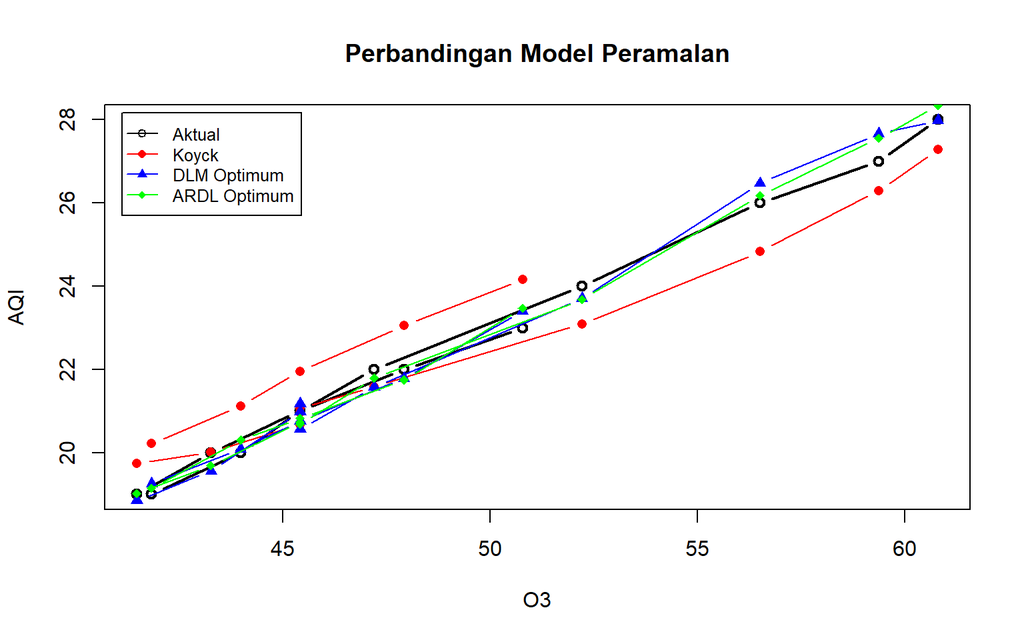

```r
# Membuat grafik perbandingan nilai aktual dan hasil forecasting
par(mfrow = c(1, 1))

plot(
  test$Xt,
  test$Yt,
  type = "b",
  col = "black",
  lwd = 2,
  ylab = "AQI",
  xlab = "O3",
  main = "Perbandingan Model Peramalan"
)

# Menambahkan hasil forecasting Model Koyck
lines(
  test$Xt,
  fore.koyck$forecasts,
  col = "red",
  type = "b",
  pch = 16
)

# Menambahkan hasil forecasting DLM optimum
lines(
  test$Xt,
  fore.dlm$forecasts,
  col = "blue",
  type = "b",
  pch = 17
)

# Menambahkan hasil forecasting ARDL optimum
lines(
  test$Xt,
  fore.ardl$forecasts,
  col = "green",
  type = "b",
  pch = 18
)

# Menambahkan keterangan pada grafik
legend(
  "topleft",
  legend = c(
    "Aktual",
    "Koyck",
    "DLM Optimum",
    "ARDL Optimum"
  ),
  col = c(
    "black",
    "red",
    "blue",
    "green"
  ),
  lty = 1,
  pch = c(1, 16, 17, 18),
  cex = 0.8,
  inset = 0.02
)
```

Berdasarkan visualisasi, grafik ini **mendukung hasil perbandingan MAPE** sebelumnya. Model DLM Optimum dan ARDL Optimum menghasilkan nilai peramalan yang lebih dekat dengan nilai AQI aktual dibandingkan model Koyck. ARDL Optimum terlihat memiliki hasil peramalan paling mendekati nilai aktual, yang sejalan dengan nilai MAPE terkecil sebesar 1.19%. Dengan demikian, ARDL Optimum memiliki kinerja peramalan terbaik di antara ketiga model.